# Seleção de Atributos

Wesley Galvão

# Seleção de atributos

## A pergunta de negócio, em termos de modelo

[figure not shown]

## As 20 colunas de partida

A aula passada virou nove tabelas em uma linha por pedido, e mediu cada coluna pela taxa de avaliação ruim por faixa, sem treinar modelo. É isto que a gold sabe no instante da compra. O alvo é `alvo`: 1 quando a nota foi 1 ou 2, 0 quando foi 4 ou 5.

| origem | colunas |
| --- | --- |
| H1. complexidade | `n_itens`, `n_produtos`, `n_vendedores`, `multi_vendedor` |
| H2. custo do frete | `valor_total`, `frete_total`, `preco_medio`, `valor_por_item`, `frete_relativo` |
| H3. distância | `distancia_km`, `mesmo_estado`, `estado_cliente` (texto) |
| H4. calendário | `prazo_prometido_dias`, `dia_da_semana`, `mes`, `hora_da_compra`, `fim_de_semana` |
| produto | `categoria` (texto) |
| pagamento | `n_parcelas`, `tipo_pagamento` (texto) |

As 17 numéricas entram como estão. Duas das três de texto entram por uma codificação: o tipo de pagamento vira quatro colunas 0/1 e o estado vira a região. A categoria fica de fora: são 74 valores, 42 deles com menos de 300 pedidos, e o one-hot criaria 74 colunas.

## Por que selecionar

- **Custo**: cada coluna em produção alguém calcula, mantém e explica.
- **Latência**: um `merge` com um milhão de linhas atrasa cada previsão.
- **Interpretação**: 10 colunas se explicam a um auditor; 40, não.
- **Desempenho**: ruído e redundância atrapalham alguns modelos, e nunca ajudam.
- **Análise exploratória**: menos colunas para olhar, e as que separam vão para o negócio e para os dashboards.
- **Redução de dimensionalidade**: menos colunas, menos memória, treino mais rápido.

## Três tipos de coluna

[figure not shown]

# O instrumento e o protocolo

## Um modelo como instrumento de medida

- Para saber se uma coluna vale a pena, é preciso medir o que ela faz por um modelo. O modelo aqui é instrumento, não assunto.
- O modelo escolhido é um **random forest**, um conjunto de árvores de decisão. Cada árvore é uma sequência de perguntas sobre as colunas (o pedido tem mais de um vendedor? o frete passa de 30 reais?) que termina em “ruim” ou “boa”.
- Ela devolve, para cada pedido, um **score** entre 0 e 1: a fração das árvores que responderam “ruim”.
- Os parâmetros do modelo não mudam na aula. O que muda é o conjunto de colunas.

## Expandir a tabela, sem hipótese

A aula passada construiu 9 colunas a partir de quatro hipóteses. A prática mais comum é construir tudo que dá e selecionar depois, com as mesmas técnicas do catálogo:

```python
expandida = expandir_gold(gold, silver, bronze)
todas = candidatas(expandida)
print(expandida.shape, "  candidatas:", len(todas))
```

```
(87908, 40)   candidatas: 37
```

| técnica | colunas novas |
| --- | --- |
| junção com outra fonte (`produtos`) | `peso_g`, `volume_cm3`, `n_fotos`, `tamanho_descricao` |
| agregação (`pagamentos`) | `n_pagamentos`, `valor_pago` |
| one-hot (aula de discretização e codificação), uma coluna 0/1 por categoria | `pag_boleto`, `pag_credit_card`, `pag_debit_card`, `pag_voucher`, `regiao_*` (5) |
| janela temporal, binarização | `n_pedidos_anteriores_vendedor`, `vendedor_sp`, `entregue` |
| data e hora, combinação | `trimestre`, `frete_por_item` |

Entram redundâncias de propósito (`valor_pago` repete `valor_total`, `trimestre` repete `mes`) e uma coluna constante. É o que a seleção vai ter para podar.

## O split por data

[figure not shown]

## Acertos, erros, revocação e precisão

[figure not shown]

## As quatro contagens

[figure not shown]

## ROC e AUC: o conceito

[figure not shown]

## Três famílias de métodos

[figure not shown]

# Filtros

## Filtros: o conceito

[figure not shown]

## Relevância univariada: o mecanismo

[figure not shown]

O F-test compara a média da coluna nos pedidos ruins com a média nos bons, dividida pela dispersão dentro de cada grupo. F alto: a coluna separa os dois grupos por si só. F perto de zero: as médias coincidem, e um p-valor acima de 0,05 diz que a diferença não passa de acaso.

## f_classif: o ranking

```python
from sklearn.feature_selection import VarianceThreshold, f_classif
seletor = VarianceThreshold(threshold=0).fit(X_treino)   # coluna constante sai
sem_constantes = list(X_treino.columns[seletor.get_support()])
F_valor, p_valor = f_classif(X_treino[sem_constantes], y_treino)
F = pd.Series(F_valor, index=sem_constantes)
sem_sinal = list(F.index[p_valor > 0.05])       # F que não se distingue de zero
```

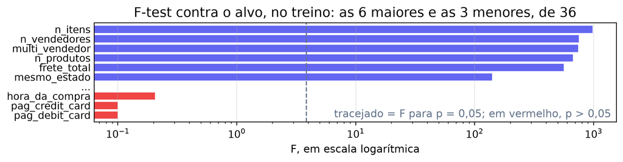

- Topo: tamanho do pedido (`n_itens`, `n_vendedores`, `multi_vendedor`, `n_produtos`) e `frete_total`, F acima de 500. Três dizem quase o mesmo.
- Base, em vermelho: pagamento e hora da compra, F abaixo de 1: a média não muda entre ruins e bons. Dez das 36 têm p > 0,05.

## Correlação entre colunas: o mecanismo

[figure not shown]

A correlação de Pearson mede quanto uma coluna acompanha a outra em linha reta. Acima de 0,85, uma das duas sai, e sai a de menor F.

## Correlação: a poda

```python
removidas, pares = podar_por_correlacao(X_treino[sem_constantes], limite=0.85, relevancia=F)
apos_correlacao = [c for c in sem_constantes if c not in removidas]
ranking_F = [c for c in F.sort_values(ascending=False).index if c in apos_correlacao]
```

```
     mantida        removida  correlacao
  valor_pago     valor_total       0.997
   trimestre             mes       0.981
n_vendedores  multi_vendedor       0.969
 valor_total     preco_medio       0.925
 valor_total  valor_por_item       0.925
  pag_boleto pag_credit_card       0.885

37 candidatas viraram 30
```

Em cada par uma coluna sai, e quem sai é decisão: aqui, a de menor F. As colunas que ficam são o ponto de partida dos wrappers e dos métodos embedded.

# Wrappers

## Wrappers: o conceito

[figure not shown]

## SFS: o mecanismo

**SFS**, *Sequential Feature Selection*: parte do conjunto vazio e, a cada passo, acrescenta a coluna que mais sobe o AUC, medido por validação cruzada em três dobras numa amostra de 10 mil linhas do treino. Aqui, até 8 colunas.

[figure not shown]

# Embedded

## Embedded: o conceito

[figure not shown]

## Impureza: o ranking do random forest

O random forest ajustado nas 30 colunas dá uma nota a cada coluna: a fração do ganho de impureza.

```python
ajustada = floresta().fit(X_treino[apos_correlacao], y_treino)
impureza = pd.Series(ajustada.feature_importances_, index=apos_correlacao)
```

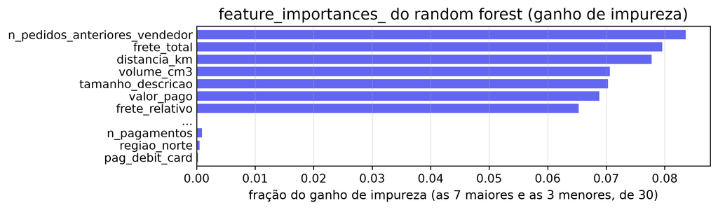

- Contínuas no topo, colunas 0/1 na base. `hora_da_compra`, que o F-test não distingue de zero, fica em 12º; `mesmo_estado`, 6ª pelo F-test, cai para 20º: o viés da impureza.

## SelectFromModel: o mecanismo

[figure not shown]

Ter uma importância por coluna não é ter uma seleção: falta a régua. `SelectFromModel` é a régua embalada como transformador, e herda o critério de quem dá a importância.

# Fechamento

## O que cada método escolheu

|  | F-test, top 10 | SFS, 8 | impureza, top 10 | SelectFromModel, 15 | métodos |
| --- | --- | --- | --- | --- | --- |
| n_itens | x | x | x | x | 4 |
| distancia_km | x |  | x | x | 3 |
| valor_pago | x |  | x | x | 3 |
| prazo_prometido_dias | x | x |  | x | 3 |
| frete_por_item | x |  | x | x | 3 |
| frete_total | x |  | x | x | 3 |
| n_vendedores | x | x |  | x | 3 |
| frete_relativo |  |  | x | x | 2 |
| mesmo_estado | x | x |  |  | 2 |
| peso_g |  |  | x | x | 2 |
| n_produtos | x |  |  | x | 2 |
| tamanho_descricao |  |  | x | x | 2 |
| n_pedidos_anteriores_vendedor |  |  | x | x | 2 |
| trimestre |  | x |  | x | 2 |

## O método campeão

|  | colunas | AUC no teste | topo de 10% da fila |
| --- | --- | --- | --- |
| as 37 candidatas | 37 | 0,630 | 22,7% dos ruins |
| as 30 após a correlação | 30 | 0,639 | 23,5% dos ruins |
| F-test, top 10 | 10 | 0,595 | 21,3% dos ruins |
| SFS, 8 | 8 | 0,629 | 25,9% dos ruins |
| impureza, top 10 | 10 | 0,602 | 20,4% dos ruins |
| SelectFromModel, 15 | 15 | 0,632 | 22,9% dos ruins |

- Com 4.792 pedidos ruins no teste, o **erro padrão** do AUC fica perto de 0,005: diferenças abaixo de 0,01 não separam métodos.
- F-test e impureza, com 10 colunas, perdem 0,03 de AUC. `SelectFromModel` segura o AUC, mas com 15 colunas.
- **O campeão é o SFS**: 8 colunas, o AUC das 37 dentro do erro padrão e o melhor topo da fila, 25,9% dos ruins. É a tabela final.

## As 37 contra as 8: a curva ROC

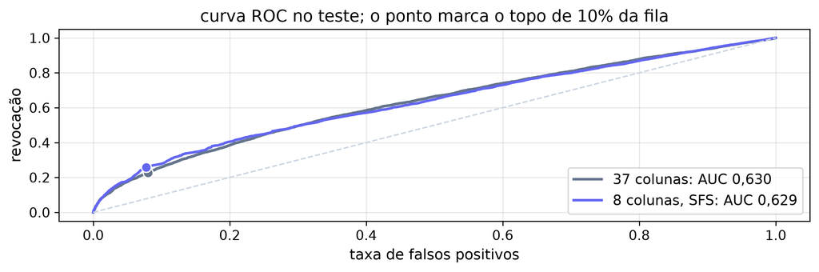

- AUC igual, dentro do erro padrão: no conjunto, as duas filas têm a mesma ordem.
- A curva das 8 sobe mais cedo e fica abaixo no meio. No topo de 10% da fila, as 8 alcançam 25,9% dos ruins e as 37, 22,7%, diferença maior que o erro padrão.

## A tabela final e o que ela custa

```
as 37    37 colunas   AUC 0.630   topo de 10% da fila: 22.7% dos ruins
as 8      8 colunas   AUC 0.629   topo de 10% da fila: 25.9% dos ruins
```

|  | o que custa em produção |
| --- | --- |
| n_itens | groupby sobre os itens do pedido |
| n_vendedores | groupby sobre os itens do pedido |
| mesmo_estado | merge com clientes e com vendedores |
| prazo_prometido_dias | nada: está no pedido |
| pag_debit_card | nada: está no pedido |
| regiao_sul | nada: está no pedido |
| vendedor_sp | merge com a tabela de vendedores |
| trimestre | nada: está no pedido |

Oito colunas fazem o que 37 fazem, e nenhuma exige a geolocalização nem o histórico do vendedor. `trimestre` não custa nada, mas é calendário: o padrão que o modelo aprendeu com ela no treino vale no ano seguinte?

## Prós e contras, lado a lado

| método | a favor | contra |
| --- | --- | --- |
| poda por correlação | um cálculo por par, sem modelo | só enxerga pares, e só relação em linha reta |
| `f_classif` | uma estatística por coluna, barata | univariada: não vê redundância nem interação |
| `SequentialFeatureSelector` | o critério é a métrica que se quer | 636 ajustes; depende do modelo e da amostra |
| `feature_importances_` | sai de graça do treino | a impureza infla coluna contínua sem sinal |
| `SelectFromModel` | um ajuste, e entra no `Pipeline` | herda o viés de quem dá a importância |

Outros métodos das mesmas famílias: `VarianceThreshold` retira colunas de variância abaixo de um limiar; o **VIF** (*Variance Inflation Factor*) mede quanto cada coluna é explicada pelas outras, e enxerga redundância entre grupos, não só entre pares; o **RFE** (*Recursive Feature Elimination*) parte de todas as colunas e retira, a cada rodada, a de menor importância; a **importância por permutação** embaralha uma coluna em dados que o modelo não viu e mede quanto o AUC cai; o **L1** (*lasso*) zera coeficientes durante o treino de um modelo linear.

## O que os pipelines de produção usam

| família | como escolhe | no sklearn | em produção |
| --- | --- | --- | --- |
| filtro | uma estatística por coluna, sem modelo | `SelectKBest`, `f_classif` | sim, como primeira peneira: é o mais barato |
| wrapper | ajusta o modelo em cada subconjunto | `SequentialFeatureSelector`, `RFE` | raro: centenas de ajustes não cabem no dia a dia |
| embedded | o próprio treino pesa as colunas | `feature_importances_`, L1 | sim, e é a leitura que o time discute |
| transformador baseado em modelo | um ajuste e um corte na importância | `SelectFromModel` | sim: é o que entra no `Pipeline` e escala |

- **XGBoost, LightGBM e CatBoost**, de *gradient boosting*, oferecem mais de uma importância, todas com o viés visto aqui.
- **SHAP** (*SHapley Additive exPlanations*) decompõe o score de cada pedido por coluna. **Boruta** cria cópias embaralhadas e só mantém quem supera a melhor delas.

## Onde isso continua

- A gold da aula passada continua no disco, e a tabela expandida se refaz com uma chamada. O exercício prático parte daí.
- **Reduzir a dimensão** é o outro caminho: em vez de manter colunas originais, o PCA cria colunas novas, combinações das originais. Serve quando há centenas de colunas parecidas, como pixels ou palavras, e ninguém precisa nomear cada uma.
- O que ficou de fora: validação cruzada aninhada, para que o próprio `k` não seja escolhido olhando o teste; estabilidade da seleção entre reamostragens; e o custo de cada coluna como parte do critério, em vez de comentário no fim.

## Referências

- García, Luengo e Herrera. *Data Preprocessing in Data Mining*, capítulo 7.
- scikit-learn: [Feature selection](https://scikit-learn.org/stable/modules/feature_selection.html).
- [Feature Selection in Python](https://www.datacamp.com/tutorial/feature-selection-python), DataCamp.
- Jason Brownlee, [How to Perform Feature Selection with Categorical Data](https://machinelearningmastery.com/feature-selection-with-real-and-categorical-data/).
- Piyush Agnihotri, [Feature Selection Techniques in Machine Learning](https://www.kaggle.com/code/piyushagni5/feature-selection-techniques-in-machine-learning), Kaggle.
- Kursa e Rudnicki, *Feature Selection with the Boruta Package*, Journal of Statistical Software, 2010.
- Lundberg e Lee, *A Unified Approach to Interpreting Model Predictions*, NeurIPS, 2017.